# Different evidence of paper demand

The STN database records several types of ‘transaction’, which have a bearing on the STN’s demand for paper. In previous analyses, I have focussed on particular ‘out’ transactions (broadly speaking, sales). By seeing how many books the STN were selling, I tried to give a sense of how many sheets of paper they were using. It turns out, however, that there are two kinds of ‘in’ transaction in the database, of particular relevance to our research: ‘in (printing)’ and ‘in (assumed printing)’ transactions record print runs; ‘Bilan’ and ‘stock take’ transactions record stock sitting in the STN’s warehouse at particular points in time

By comparing these three, independent lines of data, hopefully we can get a clearer idea of how much paper the STN was bringing in, how much they were using, and how much they were wasting.

```r
# Connect to the database and load functions and packages
source('init.R')

# Import key data
orders <- fetch_table(stn, "orders") # Each transaction is part of an overarching 'order'
editions <- fetch_table(stn, "books") %>%
  # Estimate the sheets using the 'edition' and 'pages' info
  mutate(
    book_sheets = str_remove(book_sheets, "\\D") %>% as.numeric(),
    total_pages = sum_pages(pages),
    leaves = str_replace(edition, "[Ff]olio", "2") %>% str_remove("\\D") %>% as.numeric(),
    sheets_estimate = calculate_sheets(total_pages, leaves)
  ) # Each transaction concerns a particular edition
transactions <- fetch_table(stn, "transactions") %>% # Load transaction data
  left_join(orders, by = "order_code") %>% # Join to order information (e.g. to get dates)
  left_join(editions, by = "book_code") # Joine to edition information (e.g. to get format details)
```

# Section 1: The big picture

We do not know how comprehensive the data is, or how these different pieces fit together. The simplest thing to do is to see how many volumes are recorded for each book in each category of transaction, and see if the books balance.

The basic accounting unit in the database is ‘volumes exchanged’. So to begin, let’s see how many volumes were exchanged for each unique transaction type:

```r
transactions %>%
  group_by(direction_of_transaction) %>%
  summarise(
    volumes_exchanged = sum(total_number_of_volumes, na.rm = T),
    na_transactiosn = sum(is.na(total_number_of_volumes))
  ) %>%
  kable() %>%
  kable_styling(full_width = F) %>%
  scroll_box(height = '200px')
```

| direction_of_transaction | volumes_exchanged | na_transactiosn |
| --- | --- | --- |
| Bilan | 440129 | 0 |
| Bilan (adjustment) | 215 | 0 |
| Bilan de sortie | 40132 | 0 |
| Catalogue | 10 | 0 |
| Commission | 786 | 0 |
| In | 318644 | 0 |
| In (assumed printing) | 228203 | 0 |
| In (Durand commission) | 12069 | 0 |
| In (found) | 469 | 0 |
| In (other) | 7243 | 0 |
| In (printing) | 251238 | 0 |
| In (profit and loss) | 2 | 0 |
| In (recount) | 1439 | 0 |
| In (rétiré) | 8322 | 0 |
| In (return) | 12360 | 0 |
| In (transfer) | 5781 | 0 |
| Out | -807224 | 3 |
| Out (binders) | -411 | 0 |
| Out (Durand commission) | -45451 | 0 |
| Out (faults) | -864 | 0 |
| Out (free gifts) | -2624 | 0 |
| Out (inferred) | -500 | 0 |
| Out (lost) | -6 | 0 |
| Out (missing) | -181 | 0 |
| Out (other) | -4676 | 0 |
| Out (profit and loss) | -826 | 0 |
| Out (return) | -1340 | 0 |
| out (transfer) | -14 | 0 |
| Out (transfer) | -5283 | 0 |
| Returned before arrival | 1472 | 0 |
| sales MS1003 | 683 | 0 |
| Sales MS1003 | 44027 | 0 |
| stock take | 6533 | 0 |
| Stock take | 199565 | 0 |

There are many types of transaction, and it is not clear from the FBTEE documentation what they all represent. Let us just focus on the ones specifically labelled ‘In’ and ‘Out’, and see how the totals compare.

```r
transactions %>%
  mutate(direction_of_transaction = str_to_lower(direction_of_transaction)) %>%
  # Convert ms1003 sales to negative numbers
  mutate(total_number_of_volumes = if_else(str_detect(direction_of_transaction, "^sales"), -total_number_of_volumes, total_number_of_volumes)) %>%
  filter(str_detect(direction_of_transaction, "^in|^out|^sales")) %>%
  mutate(
    direction = !str_detect(direction_of_transaction, "^in"),
    direction = map_chr(direction, function(x) {if (x) {return("Out")} else {return("In")}})
    ) %>%
  group_by(direction) %>%
  summarise(vols_exchanged = sum(total_number_of_volumes, na.rm = T))
```

| direction | vols_exchanged |
| --- | --- |
| In | 845770 |
| Out | -914110 |

The account doesn’t quite balance. How does it look if we examine only the STN editions?

```r
transactions %>%
  mutate(direction_of_transaction = str_to_lower(direction_of_transaction)) %>%
  # Convert ms1003 sales to negative numbers
  mutate(total_number_of_volumes = if_else(str_detect(direction_of_transaction, "^sales"), -total_number_of_volumes, total_number_of_volumes)) %>%
  filter(
    str_detect(direction_of_transaction, "^in|^out"), # Only ins and outs
    str_detect(edition_type, "(?<=^|\\s)STN") # only STN editions
    ) %>%
  mutate(
    direction = !str_detect(direction_of_transaction, "^in"),
    direction = map_chr(direction, function(x) {if (x) {return("Out")} else {return("In")}})
    ) %>%
  group_by(direction) %>%
  summarise(vols_exchanged = sum(total_number_of_volumes, na.rm = T))
```

| direction | vols_exchanged |
| --- | --- |
| In | 539319 |
| Out | -598965 |

What about these stocktakes? How are we to account for them? Probably the best way to look at them is to chart them over time, so we can see the warehoused stock rise and fall, and get a sense of how the stocktakes fit in with the rest of the data.

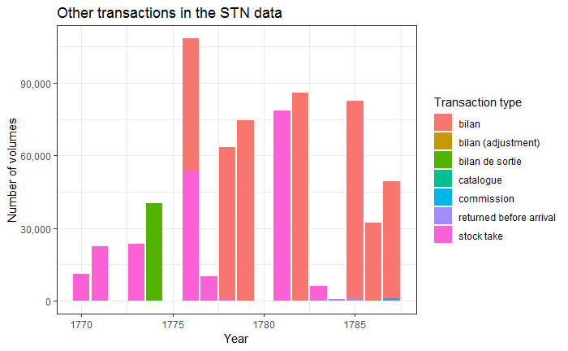

```r
transactions %>%
  mutate(direction_of_transaction = str_to_lower(direction_of_transaction)) %>%
  filter(
    !str_detect(direction_of_transaction, "^in|^out"), # exclude all 'in' and 'out' transactions
    direction_of_transaction != "sales ms1003" # and also ms1003 sales
         ) %>%
  mutate(year = lubridate::ymd(date) %>% lubridate::year()) %>%
  ggplot(aes(x = year, y = total_number_of_volumes, fill = direction_of_transaction)) +
  geom_col() +
  scale_y_continuous(labels = scales::comma_format()) +
  labs(
    title = 'Other transactions in the STN data',
    x = 'Year',
    y = 'Number of volumes',
    fill = 'Transaction type'
  ) +
  theme_bw()
```

What is ‘sales ms1003?’ It is not clear why they have been coded differently to other ‘out’ transactions. MS1003 was a different kind of document, and SB thinks it may have been coded to allow comparison with the conventionally recorded sales. One thing to check is whether any of the MS1003 sales double up on other ‘out’ transactions.

```r
transactions %>%
  # Floor to the nearest month
  mutate(year_month = lubridate::ymd(date) %>% lubridate::floor_date(unit = "month")) %>%
  group_by(super_book_code.x, year_month) %>%
  filter(
    any(direction_of_transaction == "sales MS1003"),
    any(str_detect(direction_of_transaction, "^[Oo]ut"))
    )
```

```
 11 failed to parse.
```

| transaction_code | order_code | page_or_folio_numbers | account_heading | direction_of_transaction | super_book_code.x | book_code | stn_abbreviated_title | total_number_of_volumes | notes.x | client_code | place_code | date | manuscript_number | manuscript_type | balle_number | cash | super_book_code.y | edition_status | edition_type | full_book_title | short_book_titles | translated_title | translated_language | languages | stated_publishers | actual_publishers | stated_publication_places | actual_publication_places | stated_publication_years | … |
| --- | --- | --- | --- | --- | --- | --- | --- | --- | --- | --- | --- | --- | --- | --- | --- | --- | --- | --- | --- | --- | --- | --- | --- | --- | --- | --- | --- | --- | --- | --- |
| tr0000011 | or0006429 | 279 | nos editions | Out | spbk0000481 | bk0002056 | Fanny Spingler | -4 | NA | cl0839 | pl190 | 17820520 | 1036 | Brouillard D | D.H. n.155. | 0 | spbk0000481 | Certain | STN editions | Dangers (les) de la calomnie, ou Mémoires de Fanny Spingler: histoire angoise | Dangers (les) de la calomnie ou Mémoires de Fanny Spingler: histoire angoise; Dangers de la calomnie; Fanny Spingler; Mémoires de Spingler | NA | NA | French | Société Typographique de Neuchâtel | NA | Neuchâtel | Neuchâtel | 1781 | … |
| tr0000013 | or0006436 | 281 | nos editions | Out | spbk0000481 | bk0002056 | Fanny Spingler | -10 | NA | cl1290 | pl270 | 17820523 | 1036 | Brouillard D | M.R. n.161. | 0 | spbk0000481 | Certain | STN editions | Dangers (les) de la calomnie, ou Mémoires de Fanny Spingler: histoire angoise | Dangers (les) de la calomnie ou Mémoires de Fanny Spingler: histoire angoise; Dangers de la calomnie; Fanny Spingler; Mémoires de Spingler | NA | NA | French | Société Typographique de Neuchâtel | NA | Neuchâtel | Neuchâtel | 1781 | … |
| tr0000031 | or0006417 | 277 | nos editions | Out | spbk0000481 | bk0002056 | Fanny Spingler | -8 | NA | cl2120 | pl419 | 17820518 | 1036 | Brouillard D | M.G. n.150. | 0 | spbk0000481 | Certain | STN editions | Dangers (les) de la calomnie, ou Mémoires de Fanny Spingler: histoire angoise | Dangers (les) de la calomnie ou Mémoires de Fanny Spingler: histoire angoise; Dangers de la calomnie; Fanny Spingler; Mémoires de Spingler | NA | NA | French | Société Typographique de Neuchâtel | NA | Neuchâtel | Neuchâtel | 1781 | … |
| tr0000067 | or0006787 | 29 | nos editions | sales MS1003 | spbk0000481 | bk0002056 | Fanny Spingler | 666 | NA | NA | NA | 17820501 | 1003 | Rencontre | NA | 0 | spbk0000481 | Certain | STN editions | Dangers (les) de la calomnie, ou Mémoires de Fanny Spingler: histoire angoise | Dangers (les) de la calomnie ou Mémoires de Fanny Spingler: histoire angoise; Dangers de la calomnie; Fanny Spingler; Mémoires de Spingler | NA | NA | French | Société Typographique de Neuchâtel | NA | Neuchâtel | Neuchâtel | 1781 | … |

The above script calls up all the `super_books` that have at least one ‘out’ transaction and one ‘ms1003 sale’ in the same month. As you can see, there is only one such `super_book` in the whole database, and it is pretty clear that the ‘ms1003 sale’ is not simply a duplicate of any of the other three. We could also just check by day…

```r
transactions %>%
  group_by(date) %>%
  filter(
    any(direction_of_transaction == "sale MS1003"),
    any(str_detect(direction_of_transaction, "^[Oo]ut"))
  )
```

| transaction_code | order_code | page_or_folio_numbers | account_heading | direction_of_transaction | super_book_code.x | book_code | stn_abbreviated_title | total_number_of_volumes | notes.x | client_code | place_code | date | manuscript_number | manuscript_type | balle_number | cash | super_book_code.y | edition_status | edition_type | full_book_title | short_book_titles | translated_title | translated_language | languages | stated_publishers | actual_publishers | stated_publication_places | actual_publication_places | stated_publication_years | … |
| --- | --- | --- | --- | --- | --- | --- | --- | --- | --- | --- | --- | --- | --- | --- | --- | --- | --- | --- | --- | --- | --- | --- | --- | --- | --- | --- | --- | --- | --- | --- |

# Section 2: Checking sheets estimates

In discussion of our previous analysis, SB has asked whether we can check the accuracy of our sheets estimates against the manually-entered data. The STN often used sheets of paper as their accounting unit. The manually entered data, where it is drawn directly from the STN’s books, will therefore give a ground-truth value against which our estimates can be compared.

The sheets were estimated above, when the data was imported.

There are many NA values:

```r
editions %>%
  mutate(na = is.na(sheets_estimate) | is.na(book_sheets)) %>%
  group_by(na) %>%
  summarise(n = n())
```

| na | n |
| --- | --- |
| FALSE | 265 |
| TRUE | 3722 |

In other words, there are only 265 cases where we can directly compare the estimated sheets to the manually entered value.

How well do the estimates stack up?

```r
editions %>%
  filter(!is.na(sheets_estimate), !is.na(book_sheets)) %>%
  mutate(difference = sheets_estimate - book_sheets) %>%
  select(book_code, edition_type, full_book_title, pages, total_pages, quick_pages, number_of_volumes, edition, book_sheets, sheets_estimate) %T>%
  write_excel_csv("sheets_check.csv")
```

[output not shown]

There’s a problem, because the `book_sheets` column does not appear to record the sheets required to manufacture a single copy. There is no way, for example, that `bk0001477`, a book of 624 pages, required 5675 sheets to make a single copy. This must be the amount required for printing the whole edition. On the other hand, some of the books *do* simply record the sheets required for a single copy. For example, `bk0002338` has a `book_sheets` value of 26, which is identical to my calculated `sheets_estimate` of 26.

Can we take account of the print run data, and see if the `book_sheets` column makes sense then?

```r
transactions %>%
  filter(str_detect(direction_of_transaction, "printing")) %>%
  group_by(book_code) %>%
  summarise(total_vols_moved = sum(total_number_of_volumes, na.rm = T)) %>%
  left_join(editions, by = "book_code") %>%
  mutate(
    sheets_per_copy = book_sheets / number_of_volumes / total_vols_moved
  ) %>%
  select(book_code, total_pages, book_sheets, sheets_estimate, sheets_per_copy) %>%
  drop_na()
```

| book_code | total_pages | book_sheets | sheets_estimate | sheets_per_copy |
| --- | --- | --- | --- | --- |
| bk0000101 | 396 | 25 | 25 | 0.0487329435 |
| bk0000243 | 56 | 35 | 4 | 0.0233333333 |
| bk0000654 | 41 | 5 | 3 | 0.0819672131 |
| bk0000875 | 118 | 10 | 8 | 0.0099700897 |
| bk0001092 | 550 | 35 | 35 | 0.0110759494 |
| bk0001442 | 1782 | 75 | 75 | 0.0111342043 |
| bk0001902 | 166 | 7 | 7 | 0.0053846154 |
| bk0001906 | 254 | 16 | 16 | 0.0154888674 |
| bk0001922 | 1098 | 46 | 46 | 0.0034534535 |
| bk0001937 | 102 | 65 | 7 | 0.1287128713 |

[output cut: 65 more lines]

This doesn’t address the issue of the books with absurdly large `book_sheets` entries. None of them, apparently, have any print run data. Are they found in the stocktake information?

```r
transactions %>%
  filter(!str_detect(direction_of_transaction, regex("^out|^in", ignore_case = T))) %>%
  group_by(book_code) %>%
  summarise(total_vols_moved = sum(total_number_of_volumes, na.rm = T)) %>%
  left_join(editions, by = "book_code") %>%
  mutate(
    sheets_per_copy = book_sheets / number_of_volumes / total_vols_moved
  ) %>%
  select(book_code, total_pages, book_sheets, sheets_estimate, sheets_per_copy) %>%
  drop_na()
```

[output not shown]

How many of the STN editions do we now have some kind of estimate for?

```r
editions %>%
  filter(str_detect(edition_type, "(?<=^|\\s)STN")) %>%
  summarise(
    n = n(),
    with_manual_sheets = (!is.na(book_sheets)) %>% sum(),
    with_estimate = (!is.na(sheets_estimate)) %>% sum(),
    with_neither = (is.na(book_sheets) & is.na(sheets_estimate)) %>% sum(),
    only_manual = (!is.na(book_sheets) & is.na(sheets_estimate)) %>% sum()
  )
```

| n | with_manual_sheets | with_estimate | with_neither | only_manual |
| --- | --- | --- | --- | --- |
| 247 | 95 | 186 | 45 | 16 |

```r
editions %>%
  filter(
    str_detect(edition_type, "(?<=^|\\s)STN"),
    !is.na(book_sheets),
    is.na(sheets_estimate)
  ) %>%
  select(book_code, full_book_title, quick_pages, total_pages, edition, book_sheets)
```

| book_code | full_book_title | quick_pages | total_pages | edition | book_sheets |
| --- | --- | --- | --- | --- | --- |
| bk0000091 | Jeu (le) des trois sept | NA | NA | 12 | 1 |
| bk0000094 | Introduction à la connaissance géographique et politique des Etats de l'Europe | NA | NA | 8 | 11 |
| bk0001292 | Maître de la langue allemande ou nouvelle Grammaire allemande... composée sur le modèle des meilleurs auteurs de nos jours et principalement sur celui de M. le Prof. Gottsched | NA | NA | NA | 35 |
| bk0001300 | Histoire des conquêtes de Gustave-Adolfe, roi de Suède, en Allemagne ou Campagnes de ce monarque en 1630, 1631, 1632, précédées d'une introduction contenant l'origine & le commencement de la guerre de… | NA | NA | NA | 27 |
| bk0001490 | Incas (les), ou la destruction de l'empire du Pérou | NA | NA | 12 | 29 |
| bk0001579 | [Abrégé de l'histoire sainte et du catéchisme] | NA | NA | NA | 6 |
| bk0001660 | Collection complète des oeuvres de Madame Riccoboni | NA | NA | 8 | 160 |
| bk0001932 | Apologie du marquis de Fogliani, ci-devant vice roi de Naples | NA | NA | 4 | 3 |
| bk0002266 | Histoire philosophique et politique des établissements et du commerce des Européens dans les deux Indes | NA | 3670 | NA | 360 |
| bk0002631 | Thévenon (le), ou Les journées de la montagne | 490 | 492 | NA | 205 |

[output cut: 6 more lines]